# Introduccion a genomica poblacional y ancestria

Curso Genetica y Genomica en Produccion Animal

Dr. Jose A. Gallardo, Nicol Delgado.

Pontificia Universidad Catolica de Valparaiso  
jose.gallardo@pucv.cl

01 July 2021

### FORMATO PLINK

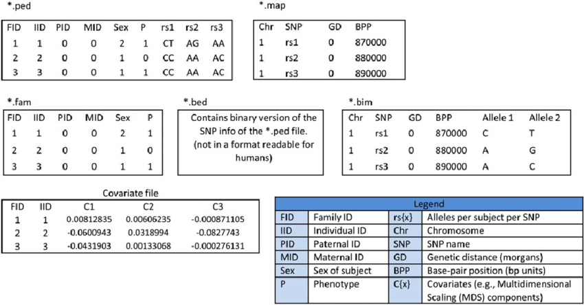

Estructura formato PLINK, tomado de: https://www.researchgate.net/figure/Overview-of-various-commonly-used-PLINK-files-SNP-single-nucleotide-polymorphism_fig3_323424714

### SOFTWARES DE BIOINFORMATICA

PLINK

PLINK es un conjunto de herramientas de analisis de asociación de genoma completo de codigo abierto y gratuito, disenado para realizar una variedad de análisis genéticos básicos a gran escala de forma eficiente (https://www.cog-genomics.org/plink2).

ADMIXTURE

ADMIXTURE es un software para estimar la maxima probabilidad de ancestria individual e inferir poblaciones a partir de un conjunto de datos de genotipos de multiples SNP. Utiliza el mismo modelo estadistico que el software STRUCTURE pero el algoritmo de optimizacion numerico que utiliza realiza estimaciones con mayor rapidez (https://bioinformaticshome.com/tools/descriptions/ADMIXTURE.html).

### LIBRERIAS R

Para elaborar algunas gráficas se usarán las siguientes librerías de R

**ggplot2** **readr** **dplyr** **tidyverse** **cowplot**

### Objetivos del trabajo practico

- Realizar un analisis de genomica poblacional y ancestria en *Salmo salar* a partir de archivo de variantes VCF.

### Origen de las muestras

El archivo vcf contiene muestras provenientes de tres poblaciones domesticadas de salmon del Atlantico (*Salmo salar*) provenientes de Europa, Oceania y Norteamerica.

### Etapas del analisis poblacional

-Descarga del archivo vcf

-Estimacion de algunas medidas comunes de diversidad genetica

-Transformacion del archivo vcf a formato plink

-Transformacion del archivo plink a formato plink binario

-Filtrado por equilibrio de Hardy-Weinberg, frecuencia del alelo menor, desequilibrio de ligamiento e individuos emparentados

-Analisis y deteccion de estructura poblacional con PLINK o ADMIXTURE

-Visualizacion de la subestructura de la poblacion mediante graficas realizadas en R

### 1 - Conectar a servidor Pomeo

Conecte al servidor pomeo usando la siguiente direccion IP: **200.54.220.141** puerto 22.

Para MAC use la terminal y para Windows puede conectarse con el software PuTTy y las claves de acceso dadas en la primera clase.

### 2 - Configurar bioconda e instalar programas para analisis

Para configurar el canal bioconda se debe ejecutar el siguiente comando

```
conda config --add channels bioconda
```

Instalar los software plink

```
conda install -c bioconda plink
```

Instalar admixture

```
conda install -c bioconda admixture
```

### 3 - Crear directorio de trabajo “population” y preparar archivos para el analisis poblacional con plink y admixture.

Este directorio y los archivos necesarios para ejecutar esta practica ya fueron creados e instalados en su directorio personal. Por ahora solo es necesario que ingrese al directorio “population” y explore los archivos de trabajo.

3.1 - Ingresar a su directorio de trabajo **population** con el comando **cd** y liste con **ls** los archivos que estan contenidos

```
cd population
ls -l -h
```

3.2 - El directorio **population** contiene los siguientes archivos necesarios para efectuar el analisis poblacional con plink y admixture.

**EU_OC_US.vcf**  
Archivo vcf que contiene las muestras provenientes de tres poblaciones de salmon del Atlantico (*Salmo salar*).

**Europa**: 2_WG0341511-DNA_A02_5408, 3_WG0341511-DNA_A03_5416, 5_WG0341511-DNA_A05_5450.

**Oceania**: FR07958834, FR07958842, FR07958850.

**Norteamerica**: GNB12-1, GNB12-10, GNB12-11.

Adicionalmente, contiene un Script para realizar los diagramas de admixture.

**Admixture_plot.R**  
Script que contiene el codigo para crear una funcion llamada admixtureplot (), utilizada para realizar los diagramas de admixture.

### 4 - Analisis de diversidad

4.1 - Estimar el numero de sitios heterocigotos para cada individuo y la heterocigosidad observada y esperada para cada marcador

```
vcftools --vcf EU_OC_US.vcf --het --out EU_OC_US

vcftools --vcf EU_OC_US.vcf --hardy --out EU_OC_US
```

Utilice ls -l, head, cat, less, etc., segun corresponda, para explorar los archivos de salida de cada uno de estos analisis.

4.2 - Calcular la diversidad en una ventana no superpuesta de 200 kb para cada individuo de las tres poblaciones

### Para la poblacion de Europa

```
vcftools --vcf EU_OC_US.vcf --window-pi 200000 --indv 2_WG0341511-DNA_A02_5408 --indv 3_WG0341511-DNA_A03_5416 --indv 5_WG0341511-DNA_A05_5450 --out EU
```

### Para la poblacion de Oceania

```
vcftools --vcf EU_OC_US.vcf --window-pi 200000 --indv FR07958834 --indv FR07958842 --indv FR07958850 --out OC
```

### Para la poblacion de Norteamerica

```
vcftools --vcf EU_OC_US.vcf --window-pi 200000 --indv GNB12-1 --indv GNB12-10 --indv GNB12-11 --out US
```

4.3 - Calcular el desequilibrio de ligamiento (LD) para las tres poblaciones

### Para la poblacion de Europa

```
vcftools --vcf EU_OC_US.vcf --geno-r2 --chr 1 --ld-window-bp 100000 --min-r2 0.001 --indv 2_WG0341511-DNA_A02_5408 --indv 3_WG0341511-DNA_A03_5416 --indv 5_WG0341511-DNA_A05_5450 --out EU
```

### Para la poblacion de Oceania

```
vcftools --vcf EU_OC_US.vcf --geno-r2 --chr 1 --ld-window-bp 100000 --min-r2 0.001 --indv FR07958834 --indv FR07958842 --indv FR07958850 --out OC
```

### Para la poblacion de Norteamerica

```
vcftools --vcf EU_OC_US.vcf --geno-r2 --chr 1 --ld-window-bp 100000 --min-r2 0.001 --indv GNB12-1 --indv GNB12-10 --indv GNB12-11 --out US
```

```r
EU <- read_delim("EU.geno.ld", delim = "\t")
OC <- read_delim("OC.geno.ld", delim = "\t")
US <- read_delim("US.geno.ld", delim = "\t")

EU$dist <- ceiling((EU$POS2 - EU$POS1)/1000)*1000
OC$dist <- ceiling((OC$POS2 - OC$POS1)/1000)*1000
US$dist <- ceiling((US$POS2 - US$POS1)/1000)*1000

EU2 <- group_by(EU,dist) %>%
  summarise(meanR2 = mean(`R^2`))

OC2 <- group_by(OC,dist) %>%
  summarise(meanR2 = mean(`R^2`))

US2 <- group_by(US,dist) %>%
  summarise(meanR2 = mean(`R^2`))

dd <- bind_rows(EU2,OC2,US2)

dd$pop <- rep(c("EU","OC","US"),c(nrow(EU2),nrow(OC2),nrow(US2)))

write_csv(dd,"EU_OC_US.windowed.ld.csv")
```

4.4 - Graficos de heterogocidad individual, diversidad de nucleotidos y LD

### Heterogocidad individual

```r
het <- read_delim("EU_OC_US.het",delim = "\t")
het
```

```
## # A tibble: 9 x 5
##   INDV                     `O(HOM)` `E(HOM)` N_SITES      F
##   <chr>                       <dbl>    <dbl>   <dbl>  <dbl>
## 1 2_WG0341511-DNA_A02_5408     8443    7747.   12703 0.140
## 2 3_WG0341511-DNA_A03_5416     8209    7749.   12708 0.0927
## 3 5_WG0341511-DNA_A05_5450     8571    7749.   12707 0.166
## 4 FR07958834                  10157    7754    12715 0.484
## 5 FR07958842                  10268    7757    12719 0.506
## 6 FR07958850                  10301    7754.   12713 0.514
## 7 GNB12-1                     10618    9753.   16669 0.125
## 8 GNB12-10                     9860    9754.   16669 0.0154
## 9 GNB12-11                    10299    9754.   16670 0.0788
```

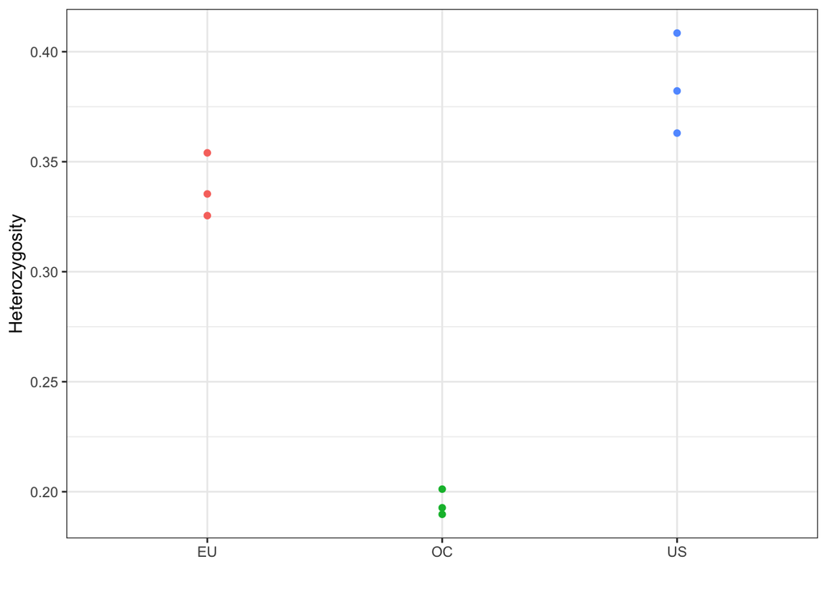

```r
het$Heterozygosity <- 1-(het$`O(HOM)`/het$N_SITES)
het$Population <- c(rep("EU",3),rep("OC",3),rep("US",3))
A <- ggplot(het,aes(x = Population, y = Heterozygosity, col = Population)) +
  geom_point()+
  theme_bw()+
  theme(legend.position = "none")+
  xlab("")
A
```

### Diversidad de nucleotidos

```r
pi_EU <- read_delim("EU.windowed.pi",delim = "\t")
pi_EU
```

```
## # A tibble: 4,903 x 5
##    CHROM BIN_START BIN_END N_VARIANTS         PI
##    <dbl>     <dbl>   <dbl>      <dbl>      <dbl>
##  1     1         1  200000          2 0.00000467
##  2     1   1000001 1200000          1 0.00000167
##  3     1   1200001 1400000          1 0.00000167
##  4     1   2200001 2400000          2 0.00000467
##  5     1   2800001 3000000          1 0.00000267
##  6     1   3000001 3200000          1 0.00000267
##  7     1   3200001 3400000          4 0.00001
##  8     1   3400001 3600000          3 0.000006
##  9     1   3600001 3800000          2 0.00000533
## 10     1   4000001 4200000          1 0.00000267
## # … with 4,893 more rows
```

```r
pi_OC <- read_delim("OC.windowed.pi",delim = "\t")
pi_OC
```

```
## # A tibble: 3,236 x 5
##    CHROM BIN_START BIN_END N_VARIANTS         PI
##    <dbl>     <dbl>   <dbl>      <dbl>      <dbl>
##  1     1         1  200000          2 0.00000533
##  2     1    200001  400000          1 0.000003
##  3     1   1200001 1400000          1 0.00000267
##  4     1   1800001 2000000          1 0.00000167
##  5     1   2200001 2400000          1 0.00000267
##  6     1   3200001 3400000          3 0.000006
##  7     1   3400001 3600000          1 0.00000167
##  8     1   4400001 4600000          2 0.00000333
##  9     1   4800001 5000000          1 0.000003
## 10     1   9000001 9200000          1 0.00000267
## # … with 3,226 more rows
```

```r
pi_US <- read_delim("US.windowed.pi",delim = "\t")
pi_US
```

```
## # A tibble: 4,774 x 5
##    CHROM BIN_START BIN_END N_VARIANTS         PI
##    <dbl>     <dbl>   <dbl>      <dbl>      <dbl>
##  1     1    200001  400000          1 0.000003
##  2     1   1000001 1200000          2 0.000006
##  3     1   1600001 1800000          1 0.00000167
##  4     1   1800001 2000000          1 0.000003
##  5     1   2200001 2400000          1 0.000003
##  6     1   2400001 2600000          1 0.000003
##  7     1   2800001 3000000          1 0.000003
##  8     1   3000001 3200000          2 0.000006
##  9     1   3200001 3400000          6 0.0000177
## 10     1   3400001 3600000          2 0.000006
## # … with 4,764 more rows
```

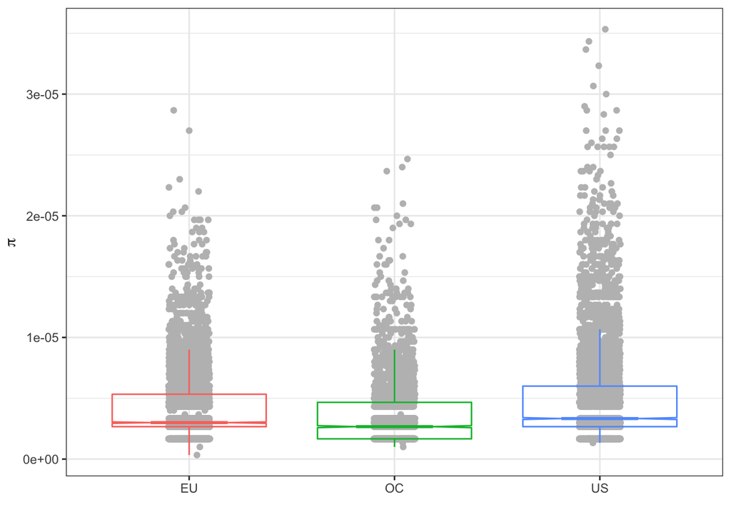

```r
pi_all <- bind_rows(pi_EU,pi_OC,pi_US)
pi_all$Population<-c(rep("EU",nrow(pi_EU)),rep("OC",nrow(pi_OC)),rep("US",nrow(pi_US)))

B <- ggplot(pi_all,aes(x = Population, y = PI, col = Population))+
      geom_jitter(col = "grey",width = 0.1)+
      geom_boxplot(notch = T, alpha = 0,outlier.shape = NA)+
      theme_bw()+
      theme(legend.position = "none")+
      xlab("")+
      ylab(expression(pi))
B
```

### Desequilibrio de ligamiento

```r
ld <- read_csv("EU_OC_US.windowed.ld.csv")
ld
```

```
## # A tibble: 256 x 3
##     dist meanR2 pop
##    <dbl>  <dbl> <chr>
##  1  1000  0.891 EU
##  2  2000  0.9   EU
##  3  3000  0.781 EU
##  4  4000  0.75  EU
##  5  5000  0.25  EU
##  6  6000  1     EU
##  7  7000  1     EU
##  8  8000  0.85  EU
##  9 10000  0.5   EU
## 10 12000  1     EU
## # … with 246 more rows
```

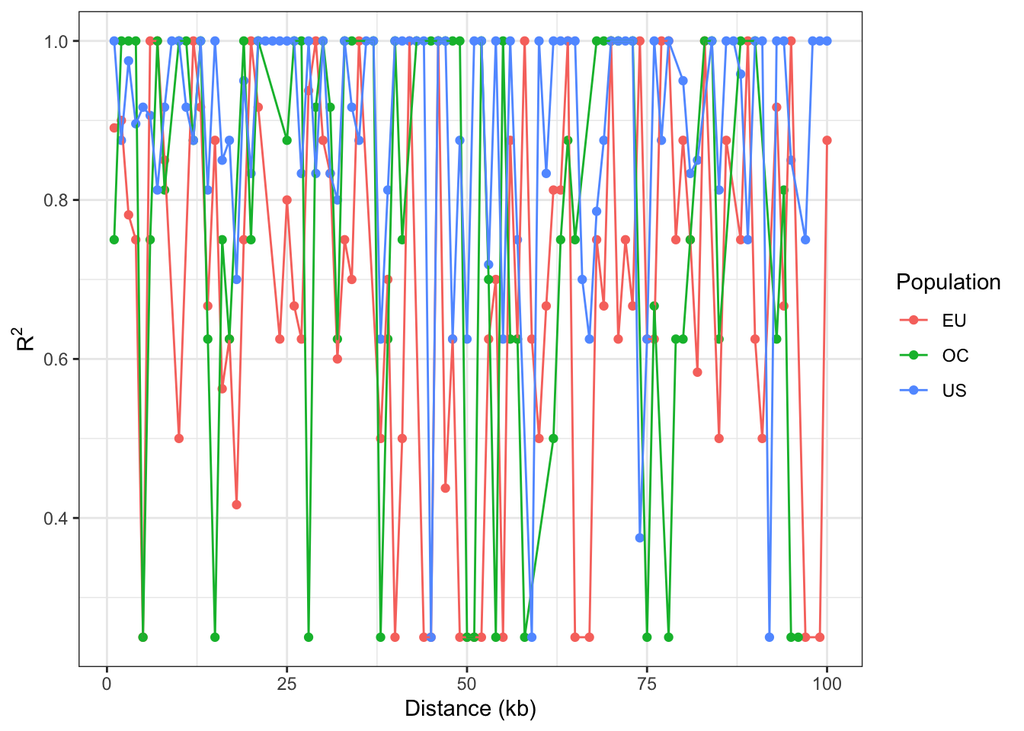

```r
C <- ggplot(ld,aes(x = dist/1000, y = meanR2, col = pop)) +
      geom_point()+
      geom_line()+
      theme_bw()+
      xlab("Distance (kb)")+
      ylab(expression(R^2))+
      scale_colour_discrete(name = "Population")
C
```

4.5 - Grafico de paneles multiples

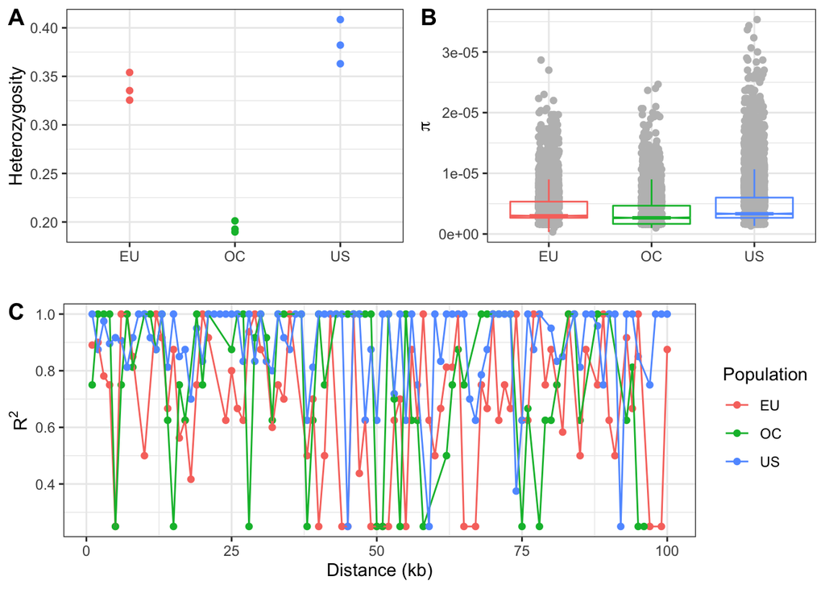

```r
library(cowplot)
top_row <- plot_grid(A,B,labels = "AUTO")
plot_grid(top_row,C,nrow = 2,labels = c("","C"))
```

### 5 - Analisis de estructura poblacional

5.1 - Generar el archivo de entrada en formato plink

```
plink --vcf EU_OC_US.vcf --recode --out EU_OC_US --double-id --allow-extra-chr --chr-set 29
```

5.2 - Generar el archivo de entrada en formato plink binario

```
plink --file EU_OC_US --make-bed --out EU_OC_US --allow-extra-chr --chr-set 29
```

5.3 - Filtrar basado en equilibrio de Hardy-Weinberg y frecuencia del alelo menor

```
plink --bfile EU_OC_US --hwe 0.01 --maf 0.05 --make-bed --out EU_OC_US.Filtered --allow-extra-chr --chr-set 29
```

5.4 - Filtrar y excluir marcadores por desequilibrio de ligamiento

```
plink --bfile EU_OC_US.Filtered --indep-pairwise 50 10 0.05 --make-bed --out EU_OC_US.Filtered --allow-extra-chr --chr-set 29

plink --bfile EU_OC_US.Filtered --extract EU_OC_US.Filtered.prune.in --make-bed --out EU_OC_US.FilteredPruned --allow-extra-chr --chr-set 29
```

5.5 - Filtrar para remover individuos relacionados

```
plink --bfile EU_OC_US.FilteredPruned --rel-cutoff 0.4 --out EU_OC_US.FilteredPruned --allow-extra-chr --chr-set 29

plink --bfile EU_OC_US.FilteredPruned --keep EU_OC_US.FilteredPruned.rel.id --make-bed --out EU_OC_US.FilteredPrunedUnrel --allow-extra-chr --chr-set 29
```

5.6 - PCA (Principal Component Analysis)

```
plink --bfile EU_OC_US.FilteredPrunedUnrel --pca 4 --out EU_OC_US.FilteredPrunedUnrel --allow-extra-chr --chr-set 29
```

5.7 - Graficos de PCA con R

```r
pca1 <- read_delim("EU_OC_US.FilteredPrunedUnrel.eigenvec", delim = " ",col_names = F)
    head(pca1)
```

```
## # A tibble: 5 x 6
##   X1                      X2                          X3     X4      X5       X6
##   <chr>                   <chr>                    <dbl>  <dbl>   <dbl>    <dbl>
## 1 3_WG0341511-DNA_A03_54… 3_WG0341511-DNA_A03_5…  0.854  -0.286  0.0340  0.00175
## 2 FR07958842              FR07958842             -0.474  -0.767 -0.0280 -0.0304
## 3 GNB12-1                 GNB12-1                -0.125   0.354  0.300  -0.747
## 4 GNB12-10                GNB12-10               -0.0875  0.335 -0.810   0.128
## 5 GNB12-11                GNB12-11               -0.151   0.305  0.502   0.651
```

```r
    colnames(pca1) <- c("Population","Individual",paste0("PC",c(1:4)))
    head(pca1)
```

```
## # A tibble: 5 x 6
##   Population              Individual                 PC1    PC2     PC3      PC4
##   <chr>                   <chr>                    <dbl>  <dbl>   <dbl>    <dbl>
## 1 3_WG0341511-DNA_A03_54… 3_WG0341511-DNA_A03_5…  0.854  -0.286  0.0340  0.00175
## 2 FR07958842              FR07958842             -0.474  -0.767 -0.0280 -0.0304
## 3 GNB12-1                 GNB12-1                -0.125   0.354  0.300  -0.747
## 4 GNB12-10                GNB12-10               -0.0875  0.335 -0.810   0.128
## 5 GNB12-11                GNB12-11               -0.151   0.305  0.502   0.651
```

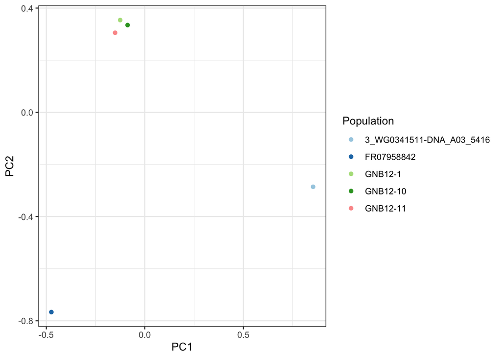

```r
    mycols <- c("#a6cee3",
              "#1f78b4",
              "#b2df8a",
              "#33a02c",
              "#fb9a99",
              "#e31a1c",
              "#fdbf6f",
              "#ff7f00",
              "#cab2d6")

    D <- ggplot(pca1,aes(x = PC1,y = PC2,col = Population))+
      geom_point()+
      theme_bw()+
      scale_colour_manual(values = mycols)
    D
```

### 6 - Analisis de admixture

6.1 Seleccion al azar del 1% de los marcadores

```
plink --bfile EU_OC_US.FilteredPrunedUnrel --thin 0.01 --make-bed --out EU_OC_US.Thinned --allow-extra-chr --chr-set 29
```

6.2 - Analisis de ancestria de 2 a 6 poblaciones

```
for K in `seq 2 6`;
do
admixture EU_OC_US.Thinned.bed $K;
done
```

ADMIXTURE genera 2 archivos: .Q que contiene asignaciones de grupos para cada individuo y .P que contiene para cada SNP las frecuencias alelicas de la poblacion

6.3 - Graficos de ADMIXTURE para 2, 4 y 6 poblaciones

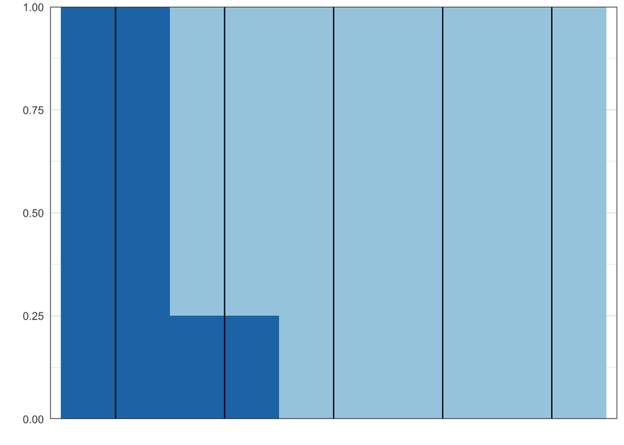

```r
library(readr)
source("Admixture_plot.R")

    pops <- read_delim("EU_OC_US.Thinned.fam", delim = " ",col_names = F)

    K2 <- read_delim("EU_OC_US.Thinned.2.Q", delim = " ",col_names = F)
    E <- admixtureplot(str_out = K2,k = 2, pops = pops, xaxis = F)
    E
```

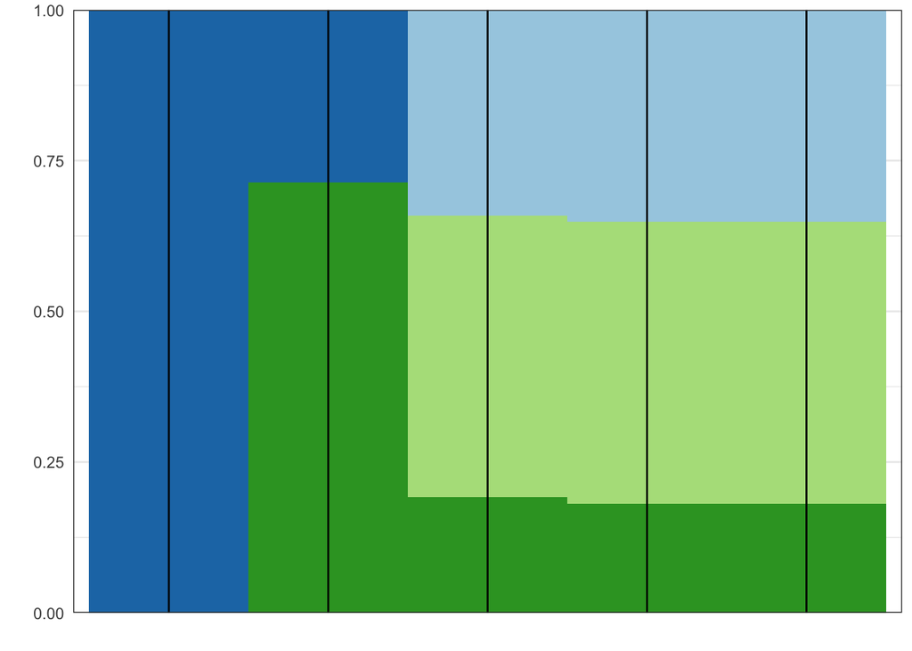

```r
    K4 <- read_delim("EU_OC_US.Thinned.4.Q", delim = " ", col_names = F)
    G <- admixtureplot(str_out = K4,k = 4, pops = pops, xaxis = F)
    G
```

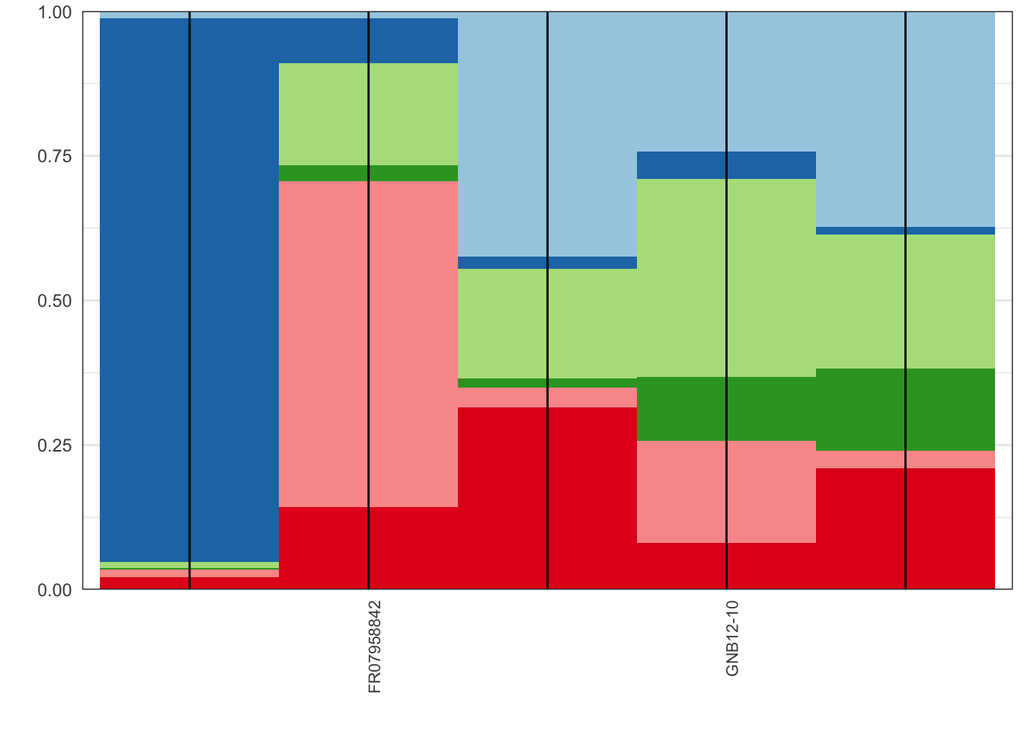

```r
    K6 <- read_delim("EU_OC_US.Thinned.6.Q", delim = " ", col_names = F)
    H <- admixtureplot(str_out = K6,k = 6, pops = pops, xaxis = T)
    H
```

### 7 - REFERENCIAS

Marees A., de Kluiver H., Stringer S., Vorspan F., Curis E., Marie-Claire C., Derks E. (2018). A tutorial on conducting genome-wide association studies: Quality control and statistical analysis. International Journal of Methods in Psychiatric Research. 27. e1608. 10.1002/mpr.1608.

A PLINK tutorial: https://zzz.bwh.harvard.edu/plink/tutorial.shtml

Speciation & Population Genomics: a how-to-guide: https://speciationgenomics.github.io/ADMIXTURE/